# Healthcare-associated infections in the US Hospitals

## Introduction

Healthcare-associated infections (HAIs) are infections people get while they're receiving health care for another condition. HAIs can happen in any health care facility, including hospitals, ambulatory surgical centers, end-stage renal disease facilities, and long-term care facilities. Bacteria, fungi, viruses, or other, less common pathogens can cause HAIs.

HAIs are a significant cause of illness and death — and they can have serious emotional, financial, and medical consequences. At any given time, about 1 in 25 inpatients have an infection related to hospital care. These infections lead to tens of thousands of deaths and cost the U.S. health care system billions of dollars each year.

```python
# Plotting the observed cases per state on the Us map
fig = px.choropleth(states_sums, locationmode= "USA-states", locations= hospitals_mean.index,
                    title = 'HAI Observed Cases per States From Jan-2018 to Dec-2019',
                    color= 'Observed_Cases', color_continuous_scale= "reds",
                    scope= "usa", labels={'Observed_Cases':'Observed Cases'},
                    width=600, height=400)


fig.show()
```

[interactive chart not shown]

## Investigation Overview

In this investigation, I wanted to look at the most common HAIs in the Us hospitals, where they apear most and how hospitals are benchmarked in their HAIs management. The main focus was on the number of patient days or operations in hospitals, the predicted cases with the lower and upper confidence level, the observed cases and the ratio of predicted over observed cases.

## Dataset Overview

Approximately 4732 hospitals where surveyed on the six HAIs:

- `HAI-1` : Central line-associated bloodstream infections
- `HAI-2` : Catheter-associated urinary tract infections
- `HAI-3` : Surgical Site Infection from colon surgery
- `HAI-4` : Surgical Site Infection from abdominal hysterectomy
- `HAI-5` : Methicillin-resistant Staphylococcus aureus (or MRSA) blood laboratory-identified events (bloodstream infections)
- `HAI-6` : Clostridium difficile (C.diff.) laboratory identified events (intestinal infections)

After removing null observations, The data consisted of 11.560 observations where The attributes included six observational numerical values, as well as the hospital information and additional categorial features such as State, HAI Category and Benchmark.

## Distribution of The Number of patient days or operations:

The Number of patient days or operations take on large values from around 10 at the lowest, to about 1 million at the highest with about 97 % of the data representing values under 100K. Plotted on a log scale, the distribution takes on a bimodal distribution with one peak between 100 and 500, and another one between 5k and 10k.

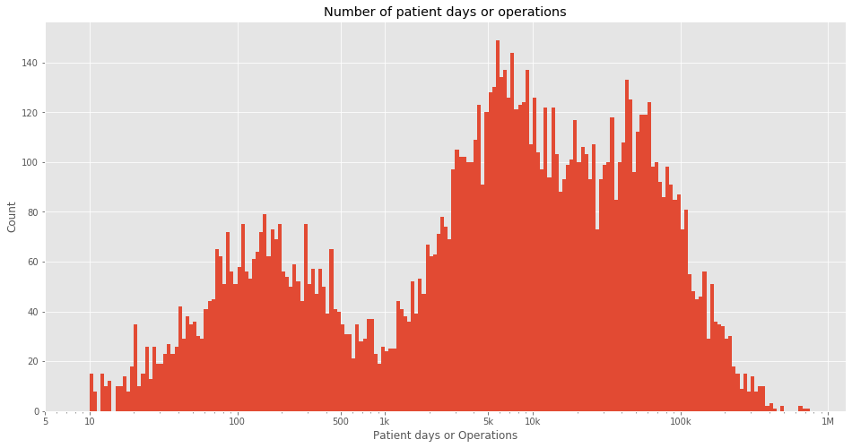

```python
bins = 10 ** np.arange(1, np.log10(positive_observations['Num_Day_Op'].max())+0.025, 0.025)
plt.figure(figsize=[16, 8])
plt.hist(data = positive_observations, x = 'Num_Day_Op', bins = bins)
plt.xscale('log')
plt.xticks([5, 10, 100, 500, 1000, 5000, 10000, 100000, 1000000], [5, 10, 100, 500, '1k', '5k', '10k', '100k', '1M'])
plt.xlabel('Patient days or Operations')
plt.ylabel('Count')
plt.title('Number of patient days or operations')
plt.show()
```

## Distribution of The Ratio of Observed cases to the Predicted ones:

The Ratio of the observed cases to the predicted ones take on values from a little above 0 at the lowest, to about 8 at the highest. Plotted on a normal scale, the distribution of the ratio takes on a righ skewed shape with a tail starting from around 2.

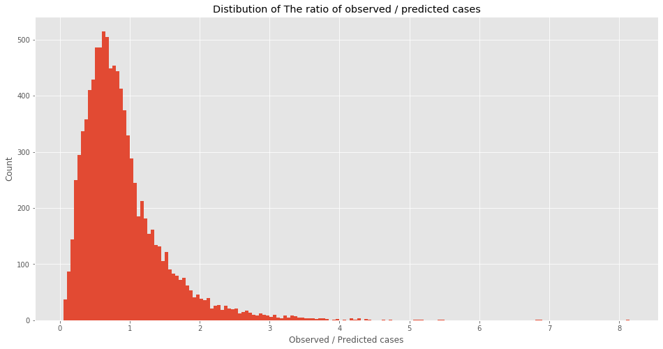

```python
binsize = 0.05
bins = np.arange(0.05, positive_observations['Ratio'].max()+binsize, binsize)

plt.figure(figsize=[16, 8])
plt.hist(data = positive_observations, x = 'Ratio', bins = bins)
plt.xlabel('Observed / Predicted cases')
plt.ylabel('Count')
plt.title('Distibution of The ratio of observed / predicted cases')
plt.show()
```

## Relationships between Patient days or Operations, Predicted Cases and Observed cases

When plotting the three numerical variables on a scatter plot we get two linear trends:

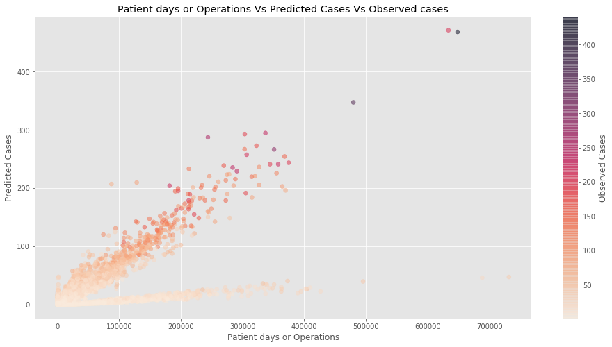

```python
plt.figure(figsize=[16,8])
plt.scatter(data = positive_observations, x= 'Num_Day_Op', y= 'Predicted_Cases', c = 'Observed_Cases',
           cmap = 'rocket_r', alpha = 0.5);
plt.xlabel('Patient days or Operations')
plt.ylabel('Predicted Cases')
plt.title('Patient days or Operations Vs Predicted Cases Vs Observed cases')
plt.colorbar(label = 'Observed Cases');
```

## Distribution of Benchmarks whithin each HAI Measure

in all the 6 HAI measures Most hospitals are no different than the national benchmark. HAI_6 has the most observations and the most top benchmarked hospitals fall in this category. HAI_4 Has the least observations, the least top and worse benchmarked hospitals.

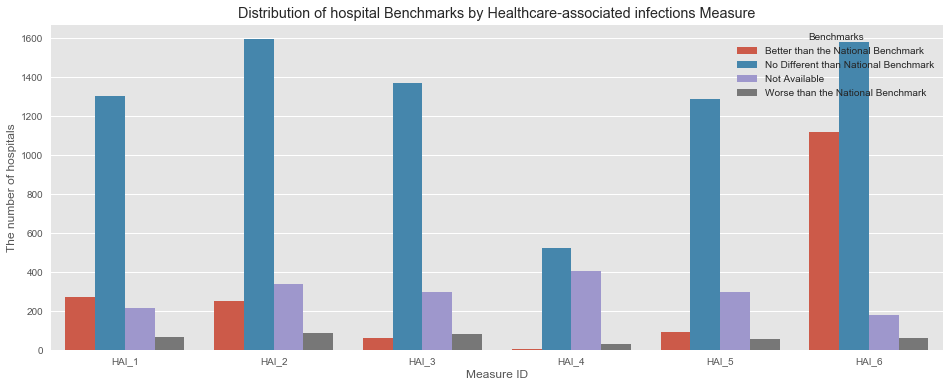

```python
plt.figure(figsize = [16,6])
sns.countplot(data = positive_observations, x= 'Measure_ID', hue = 'Compared_to_National')

plt.ylabel('The number of hospitals')
plt.xlabel('Measure ID')
plt.title('Distribution of hospital Benchmarks by Healthcare-associated infections Measure')
plt.legend(title= 'Benchmarks', loc= 'best')

plt.show()
```

## Ratio values by HAI measure and benchmark

The Medians and interquartiles of the best benchmarked hospitals for the Number of patient days or operations and predicted cases are higher than the normal and the worst hospitals, however the observed cases are less than the predicted ones,therefore a lower ratio with a lower IQR values and a maximum not exceeding the normal median opposed to the worst hospitals who have a minimum ratio bigger than the normal Q3 upper quartile.

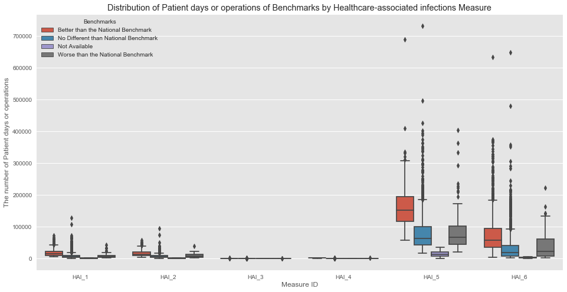

```python
plt.figure(figsize = [16,8])
sns.boxplot(data = positive_observations, x= 'Measure_ID', y= 'Num_Day_Op', hue = 'Compared_to_National')
plt.legend(loc= 'best')
plt.ylabel('The number of Patient days or operations')
plt.xlabel('Measure ID')
plt.title('Distribution of Patient days or operations of Benchmarks by Healthcare-associated infections Measure')
plt.legend(title= 'Benchmarks')

plt.show()
```

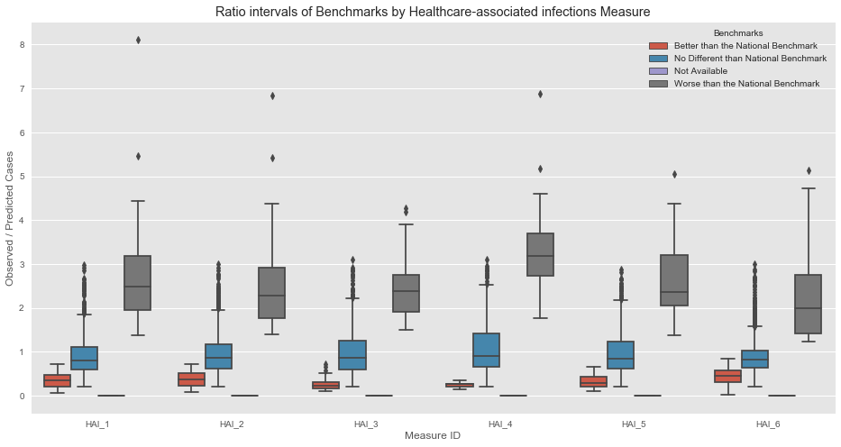

```python
plt.figure(figsize = [16,8])
sns.boxplot(data = positive_observations, x= 'Measure_ID', y= 'Ratio', hue = 'Compared_to_National')

plt.ylabel('Observed / Predicted Cases')
plt.xlabel('Measure ID')
plt.title('Ratio intervals of Benchmarks by Healthcare-associated infections Measure')
plt.legend(title= 'Benchmarks', loc= 'best')

plt.show()
```

## Distribution of Ratio intervals of Benchmarks by States

Almost in all the Us states the best benchmarked facilities have a lower median, mean and intervals than the normal hospitals, even their maximums is almost less than the normal minimum. Contarly the worst ones have a greater values almost in all states exceeding the maximum of the normal hospitals.

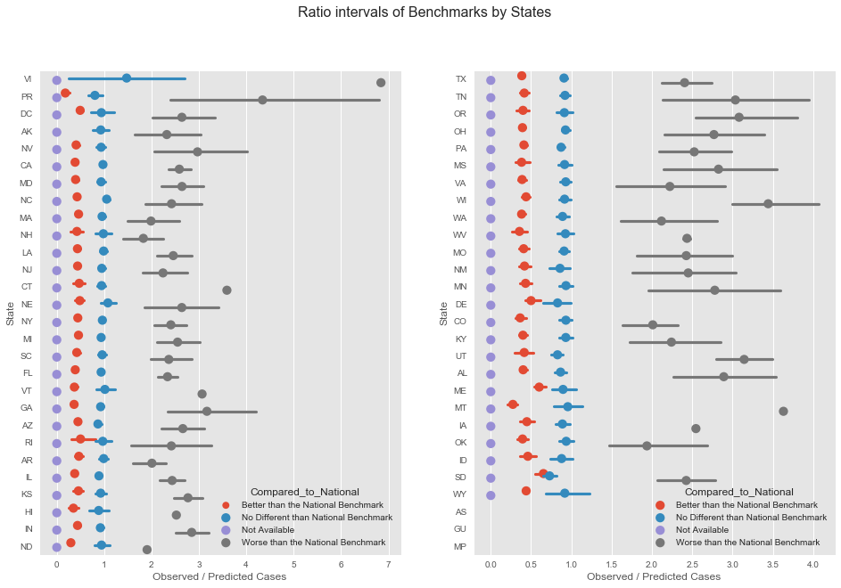

```python
# taking the list of ordered states by mean
var_order = states_means.sort_values(by= 'Ratio', ascending= False)['Ratio'].index

# Due to the number of states we are Deviding our plot to two subplots
fig, ax = plt.subplots(1, 2, figsize = [16, 10])

# left plot:
states1 = var_order[0:28]
data1 = positive_observations.query('State in @states1')
sns.pointplot(data = data1, x = 'Ratio', y = 'State', hue = 'Compared_to_National',
                   order= states1, linestyles = '', dodge = 0.4, ax= ax[0]);
ax[0].set_xlabel('Observed / Predicted Cases')

# right plot:
states2 = var_order[28:]
data2 = positive_observations.query('State in @states2')
sns.pointplot(data = data2, x = 'Ratio', y = 'State', hue = 'Compared_to_National',
                   order= states2, linestyles = '', dodge = 0.4, ax= ax[1]);
ax[1].set_xlabel('Observed / Predicted Cases')
fig.suptitle('Ratio intervals of Benchmarks by States', fontsize=16);
```

```python
fig = px.choropleth(h_states_means, locationmode= "USA-states", locations= hospitals_mean.index,
                    color= 'Benchmark', color_continuous_scale= "inferno",
                    width=600, height=400  ,
                    scope= "usa", title= 'US Hospital mean Benchmark per States')

fig.show()
```

[interactive chart not shown]

## Conclusion

Hospitals are benchmarked according to their ability to predict and manage the observed infection cases, Opposed to the worse benchmarked, The best benchmarked facilities have a lower ratio interval and mean, high patient days or operations, a low confidence levels with a highly predicted cases but a lower observed cases mean.

The Medians and interquartiles of the best benchmarked hospitals for the Number of patient days or operations and predicted cases are higher than the normal and the worst hospitals, however the observed cases are less than the predicted ones,therefore a lower ratio with a lower IQR values and a maximum not exceeding the normal median opposed to the worst hospitals who have a minimum ratio bigger than the normal Q3 upper quartile.